# R Notebook

```r
rm(list = ls())
library(dplyr)
```

## Air Pollution data

Particulate matter (less than 2.5 microns in diameter) is a fancy name for dust, and breathing in dust might pose health hazards to the population. We’ll study data from two years, 1999 (when monitoring of particulate matter started) and 2012. Our goal is to see if there’s been a noticeable decline in this type of air pollution between these two years.

Data can be downloaded at https://www.epa.gov/data

data is located in data/pm25_data folder

na.strings: a character vector of strings which are to be interpreted as NA values.

comment.char: to ignore

```r
pm0 <- read.table("data/pm25_data/RD_501_88101_1999-0.txt", sep = "|",
           header = F, comment.char = "#", na.strings = "")
dim(pm0)
```

```
[1] 117421     28
```

strsplit: Split the elements of a character vector x into substrings according to the matches to substring split within them.

This produce a list.

```r
colnames <- readLines("data/pm25_data/RD_501_88101_1999-0.txt", 1)
colnames <- strsplit(colnames, split = "|", fixed = T)
colnames[[1]]
```

```
 [1] "# RD"
 [2] "Action Code"
 [3] "State Code"
 [4] "County Code"
 [5] "Site ID"
 [6] "Parameter"
 [7] "POC"
 [8] "Sample Duration"
 [9] "Unit"
[10] "Method"
[11] "Date"
[12] "Start Time"
[13] "Sample Value"
[14] "Null Data Code"
[15] "Sampling Frequency"
[16] "Monitor Protocol (MP) ID"
[17] "Qualifier - 1"
[18] "Qualifier - 2"
[19] "Qualifier - 3"
[20] "Qualifier - 4"
[21] "Qualifier - 5"
[22] "Qualifier - 6"
[23] "Qualifier - 7"
[24] "Qualifier - 8"
[25] "Qualifier - 9"
[26] "Qualifier - 10"
[27] "Alternate Method Detectable Limit"
[28] "Uncertainty"
```

```r
names(pm0) <- colnames[[1]]
names(pm0)
```

```
 [1] "# RD"
 [2] "Action Code"
 [3] "State Code"
 [4] "County Code"
 [5] "Site ID"
 [6] "Parameter"
 [7] "POC"
 [8] "Sample Duration"
 [9] "Unit"
[10] "Method"
[11] "Date"
[12] "Start Time"
[13] "Sample Value"
[14] "Null Data Code"
[15] "Sampling Frequency"
[16] "Monitor Protocol (MP) ID"
[17] "Qualifier - 1"
[18] "Qualifier - 2"
[19] "Qualifier - 3"
[20] "Qualifier - 4"
[21] "Qualifier - 5"
[22] "Qualifier - 6"
[23] "Qualifier - 7"
[24] "Qualifier - 8"
[25] "Qualifier - 9"
[26] "Qualifier - 10"
[27] "Alternate Method Detectable Limit"
[28] "Uncertainty"
```

make names valid

```r
names(pm0) = make.names(names(pm0))
names(pm0)
```

```
 [1] "X..RD"
 [2] "Action.Code"
 [3] "State.Code"
 [4] "County.Code"
 [5] "Site.ID"
 [6] "Parameter"
 [7] "POC"
 [8] "Sample.Duration"
 [9] "Unit"
[10] "Method"
[11] "Date"
[12] "Start.Time"
[13] "Sample.Value"
[14] "Null.Data.Code"
[15] "Sampling.Frequency"
[16] "Monitor.Protocol..MP..ID"
[17] "Qualifier...1"
[18] "Qualifier...2"
[19] "Qualifier...3"
[20] "Qualifier...4"
[21] "Qualifier...5"
[22] "Qualifier...6"
[23] "Qualifier...7"
[24] "Qualifier...8"
[25] "Qualifier...9"
[26] "Qualifier...10"
[27] "Alternate.Method.Detectable.Limit"
[28] "Uncertainty"
```

pull out a variable

```r
x0 <- pm0$Sample.Value

class(x0)
```

```
[1] "numeric"
```

```r
str(x0)
```

```
 num [1:117421] NA NA NA 8.84 14.92 ...
```

Mean is right to the median.Right skewed (positive skewed)

```r
summary(x0)
```

```
   Min. 1st Qu.  Median    Mean 3rd Qu.    Max.
   0.00    7.20   11.50   13.74   17.90  157.10
   NA's
  13217
```

Large number of missing values (About 11%)

```r
mean(is.na(x0))
```

```
[1] 0.1125608
```

Let’s read 2012 data

I will use fread from data.table package

```r
library(data.table)

pm1 <- fread("data/pm25_data/RD_501_88101_2012-0.txt", sep = "|",
             header = F, na.strings = "")
```

```
|--------------------------------------------------|
|==================================================|
Warning in fread("data/pm25_data/RD_501_88101_2012-0.txt", sep = "|", header = F,  :
  Discarded single-line footer: <<# 1304287 records were written>>
```

```r
dim(pm1)
```

```
[1] 1304287      28
```

fread (data.table) is much faster and useful but, i could not make one footer row not to be read in advance. It is discarded when reading the file.

```r
system.time(pm1 <- fread("data/pm25_data/RD_501_88101_2012-0.txt", sep = "|",
             header = F, na.strings = ""))
```

```
|--------------------------------------------------|
|==================================================|
```

```
   user  system elapsed
  1.301   0.091   1.396
```

```r
system.time(pm1 <- read.table("data/pm25_data/RD_501_88101_2012-0.txt", sep = "|",
             header = F, na.strings = ""))
```

```
   user  system elapsed
  7.233   0.332   7.564
```

read file with read.table, again

```r
pm1 <- read.table("data/pm25_data/RD_501_88101_2012-0.txt", sep = "|",
             header = F, na.strings = "", comment.char = "#")
```

```r
dim(pm1)
```

```
[1] 1304287      28
```

Given the dimension of the dataset, what is the estimate size of the file?

```r
1304287 * 28 * 2^3 / 2^10  # kilo byte
```

```
[1] 285312.8
```

```r
1304287 * 28 * 2^3 / 2^20  # mega byte
```

```
[1] 278.6258
```

```r
1304287 * 28 * 2^3 / 2^30  # giga byte
```

```
[1] 0.2720955
```

```r
object.size(pm1)
```

```
187830224 bytes
```

```r
names(pm1) <- make.names(colnames[[1]])
names(pm1)
```

```
 [1] "X..RD"
 [2] "Action.Code"
 [3] "State.Code"
 [4] "County.Code"
 [5] "Site.ID"
 [6] "Parameter"
 [7] "POC"
 [8] "Sample.Duration"
 [9] "Unit"
[10] "Method"
[11] "Date"
[12] "Start.Time"
[13] "Sample.Value"
[14] "Null.Data.Code"
[15] "Sampling.Frequency"
[16] "Monitor.Protocol..MP..ID"
[17] "Qualifier...1"
[18] "Qualifier...2"
[19] "Qualifier...3"
[20] "Qualifier...4"
[21] "Qualifier...5"
[22] "Qualifier...6"
[23] "Qualifier...7"
[24] "Qualifier...8"
[25] "Qualifier...9"
[26] "Qualifier...10"
[27] "Alternate.Method.Detectable.Limit"
[28] "Uncertainty"
```

let’s pull out sample.value from pm1

```r
x1 <- pm1$Sample.Value

str(x1)
```

```
 num [1:1304287] 6.7 9 6.5 7 5.8 8 7.9 8 6 9.6 ...
```

```r
summary(x1)
```

```
   Min. 1st Qu.  Median    Mean 3rd Qu.    Max.
 -10.00    4.00    7.63    9.14   12.00  908.97
   NA's
  73133
```

```r
summary(x0)
```

```
   Min. 1st Qu.  Median    Mean 3rd Qu.    Max.
   0.00    7.20   11.50   13.74   17.90  157.10
   NA's
  13217
```

```r
mean(is.na(x1))
```

```
[1] 0.05607125
```

We see that both the median and the mean of measured particulate matter have declined from 1999 to 2012. In fact, all of the measurements, except for the maximum and missing values (Max and NA’s), have decreased. Even the Min has gone down from 0 to -10.00! We’ll address what a negative measurment might mean a little later. Note that the Max has increased from 157 in 1999 to 909 in 2012. This is quite high and might reflect an error in the table or malfunctions in some monitors.

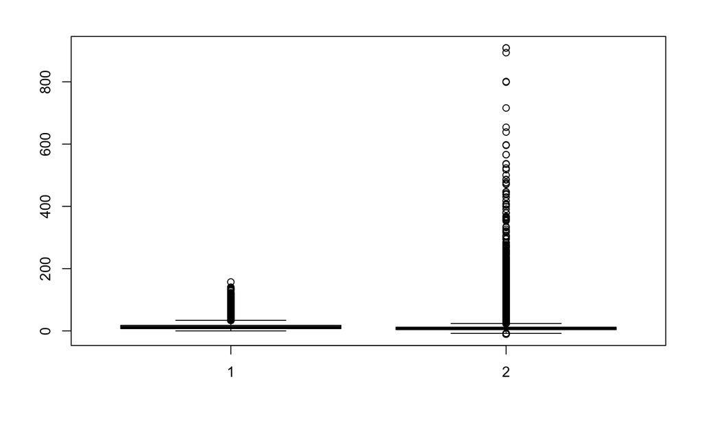

```r
boxplot(x0, x1)
```

since distributions are skewed

Also, there are negative numbersin data, this will cause warnings

```
Warning in log(x1) : NaNs produced
Warning in bplt(at[i], wid = width[i], stats = z$stats[, i], out = z$out[z$group ==  :
  Outlier (-Inf) in boxplot 1 is not drawn
Warning in bplt(at[i], wid = width[i], stats = z$stats[, i], out = z$out[z$group ==  :
  Outlier (-Inf) in boxplot 2 is not drawn
```

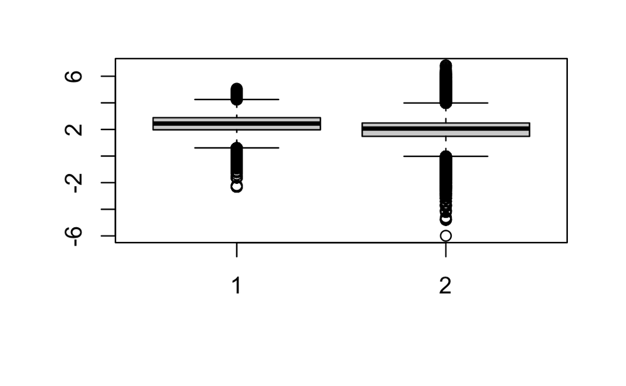

```r
boxplot(log(x0), log(x1))
```

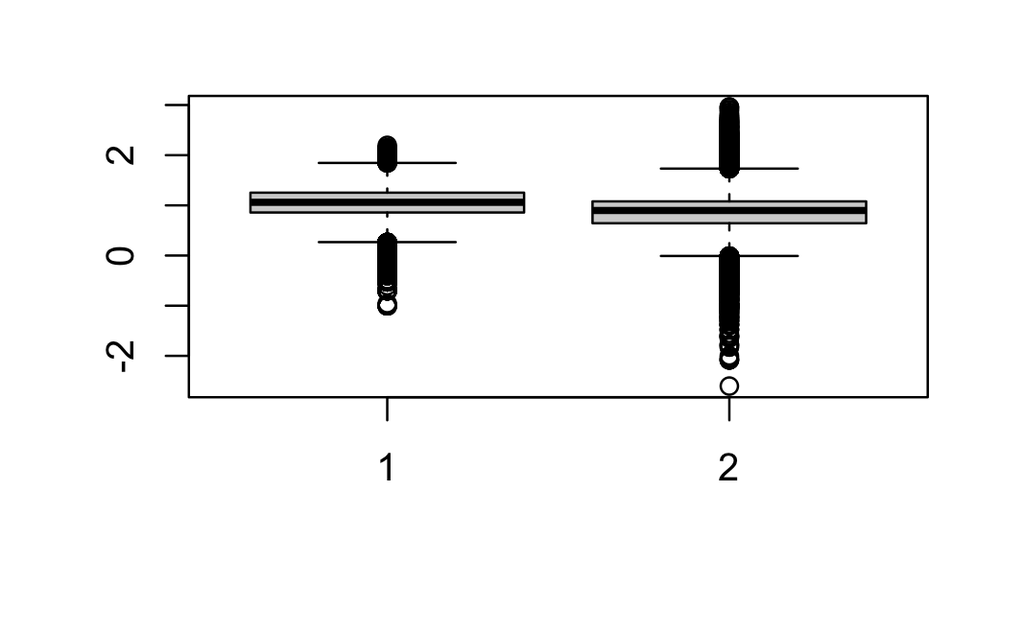

```r
boxplot(log10(x0), log10(x1))
```

Work on negtive numbers in x1 file

```r
negative  <- x1 < 0
sum(negative, na.rm = T)
```

```
[1] 26474
```

```r
mean(negative, na.rm = T)
```

```
[1] 0.0215034
```

Let’s look at dates

```r
dates <- pm1$Date
str(dates)
```

```
 int [1:1304287] 20120101 20120104 20120107 20120110 20120113 20120116 20120119 20120122 20120125 20120128 ...
```

these are in integer format, we need to convert them to date format

1. Using lubridate package

```r
library(lubridate)
dates1 <- ymd(pm1$Date)
str(dates1)
```

```
 Date[1:1304287], format: "2012-01-01" "2012-01-04" "2012-01-07" ...
```

```r
dates2 <- as.Date(as.character(dates), format = "%Y%m%d")
str(dates2)
```

```
 Date[1:1304287], format: "2012-01-01" "2012-01-04" "2012-01-07" ...
```

Histogram

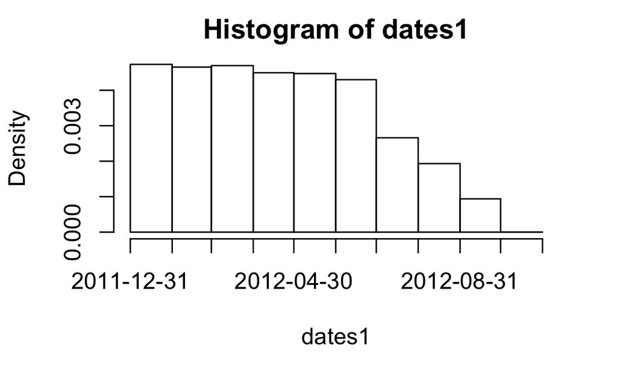

```r
hist(dates1, "month")
```

Negative tends to occur in winter months

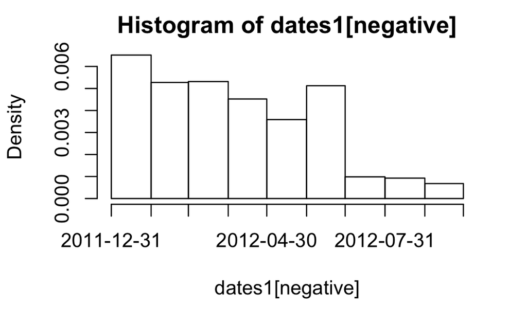

```r
hist(dates1[negative], breaks  =  "month")
```

[output not shown]

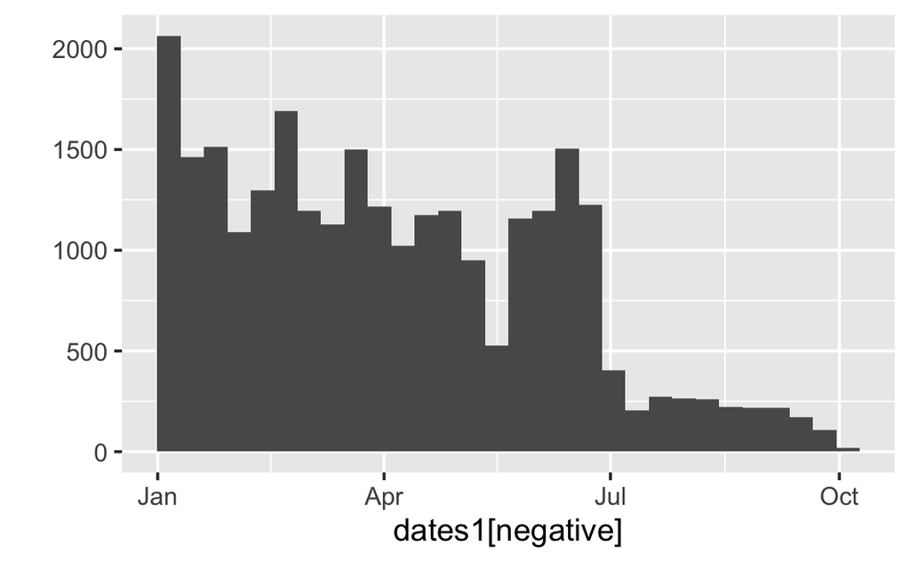

```r
library(ggplot2)
qplot(dates1[negative])
```

Now we’ll change focus a bit and instead of looking at all the monitors throughout the country and the data they recorded, we’ll try to find one monitor that was taking measurements in both 1999 and 2012. This will allow us to control for different geographical and environmental variables that might have affected air quality in different areas. We’ll narrow our search and look just at monitors in New York State.

```r
site0 <- unique(subset(pm0, State.Code == 36, c(County.Code, Site.ID)))
site1 <- unique(subset(pm1, State.Code == 36, c(County.Code, Site.ID)))
head(site0)
```

|  | County.Code | Site.ID |
| --- | --- | --- |
| 65873 | 1 | 5 |
| 65995 | 1 | 12 |
| 66056 | 5 | 73 |
| 66075 | 5 | 80 |
| 66136 | 5 | 83 |
| 66197 | 5 | 110 |

Now concatenate these selected two columns, an make and ID

```r
site10 <- paste(site0[, 1], site0[, 2], sep = ".")
site11 <- paste(site1[, 1], site1[, 2], sep = ".")
head(site10)
```

```
[1] "1.5"   "1.12"  "5.73"  "5.80"  "5.83"  "5.110"
```

Now compare/find intersection of monitor/county combinations in both datasets

```r
both <- intersect(site10, site11)
both
```

```
 [1] "1.5"     "1.12"    "5.80"    "13.11"
 [5] "29.5"    "31.3"    "63.2008" "67.1015"
 [9] "85.55"   "101.3"
```

We have 10 monitor/county combinations in both datasets

```r
pm0$county.site <- with(pm0, paste(County.Code, Site.ID, sep = "."))
pm1$county.site <- with(pm1, paste(County.Code, Site.ID, sep = "."))
```

Subset data to New York state

```r
newyork0 <- subset(pm0, State.Code==36 & county.site %in% both)
newyork1 <- subset(pm1, State.Code==36 & county.site %in% both)
```

Now take a look at how many observations we have in each monitoring sites

```r
unique(newyork0$county.site)
```

```
 [1] "1.5"     "1.12"    "5.80"    "13.11"
 [5] "29.5"    "31.3"    "63.2008" "67.1015"
 [9] "85.55"   "101.3"
```

```r
table(newyork0$county.site)
```

```
   1.12     1.5   101.3   13.11    29.5    31.3
     61     122     152      61      61     183
   5.80 63.2008 67.1015   85.55
     61     122     122       7
```

```r
table(newyork1$county.site)
```

```
   1.12     1.5   101.3   13.11    29.5    31.3
     31      64      31      31      33      15
   5.80 63.2008 67.1015   85.55
     31      30      31      31
```

Alternatively

```r
sapply(split(newyork0, newyork0$county.site), nrow)
```

```
   1.12     1.5   101.3   13.11    29.5    31.3
     61     122     152      61      61     183
   5.80 63.2008 67.1015   85.55
     61     122     122       7
```

```r
sapply(split(newyork1, newyork1$county.site), nrow)
```

```
   1.12     1.5   101.3   13.11    29.5    31.3
     31      64      31      31      33      15
   5.80 63.2008 67.1015   85.55
     31      30      31      31
```

Now focus on county 63 monitor 2008

```r
pm0sub <- subset(pm0, State.Code == 36 & County.Code == 63 & Site.ID == 2008)
pm1sub <- subset(pm1, State.Code == 36 & County.Code == 63 & Site.ID == 2008)

dim(pm0sub)
```

```
[1] 122  29
```

```r
dim(pm1sub)
```

```
[1] 30 29
```

No visualize how pm data changes overtime in a year.

```r
x0sub <- pm0sub$Sample.Value
x1sub <- pm1sub$Sample.Value


dates10 <- as.Date(as.character(pm0sub$Date), format = "%Y%m%d")
dates11 <- as.Date(as.character(pm1sub$Date), format = "%Y%m%d")

str(dates10)
```

```
 Date[1:122], format: "1999-07-02" "1999-07-05" "1999-07-08" ...
```

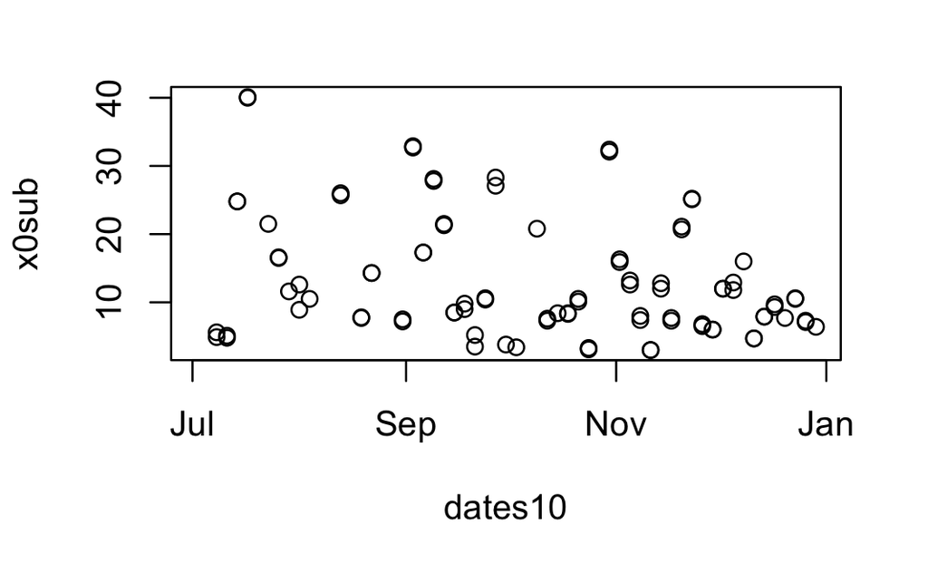

```r
plot(dates10, x0sub)
```

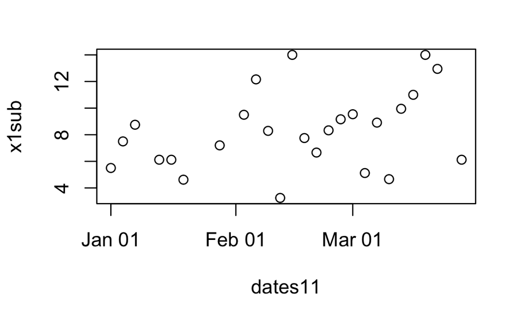

```r
plot(dates11, x1sub)
```

Make panel of plots

```r
par(mfrow = c(1, 2), mar = c(4, 4, 2, 1))
plot(dates10, x0sub, pch = 20)
abline(h = median(x0sub, na.rm = T))
```

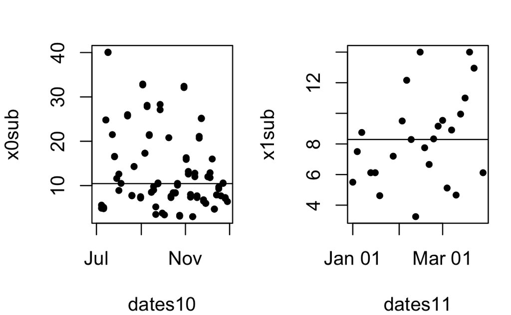

```r
plot(dates11, x1sub, pch = 20)
abline(h = median(x1sub, na.rm = T))
```

```r
range <- range(x0sub, x1sub, na.rm = T)
range
```

```
[1]  3.0 40.1
```

```r
par(mfrow = c(1, 2), mar = c(4, 4, 2, 1))
plot(dates10, x0sub, pch = 20, ylim = range)
abline(h = median(x0sub, na.rm = T))
```

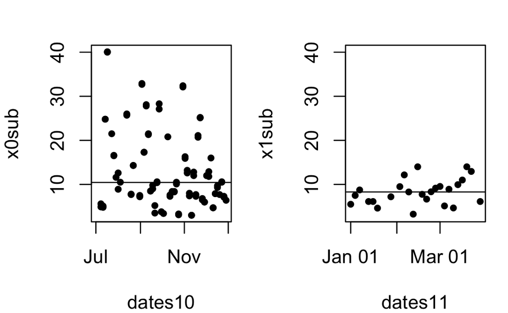

```r
plot(dates11, x1sub, pch = 20, ylim = range)
abline(h = median(x1sub, na.rm = T))
```

Now, analyze statewise differences. The last avenue of this data we’ll explore (and we’ll do it quickly) concerns a comparison of all the states’ mean pollution levels. This is important because the states are responsible for implementing the regulations set at the federal level by the EPA.

```r
mean0 <- with(pm0,
     tapply(Sample.Value, State.Code, mean, na.rm = T))
mean0
```

```
        1         2         4         5         6
19.956391  6.665929 10.795547 15.676067 17.655412
        8         9        10        11        12
 7.533304 13.276085 14.492895 15.786507 11.137139
       13        15        16        17        18
19.943240  4.861821  9.321034 16.724550 15.639703
       19        20        21        22        23
11.523740 12.391900 16.039906 14.293732  9.519416
       24        25        26        27        28
15.985083 12.314527 13.819438 10.090739 16.297349
       29        30        31        32        33
13.555692  9.199872  9.167770  9.235101 11.836578
       34        35        36        37        38
13.866028  6.511285 12.453519 15.760104  7.988184
       39        40        41        42        44
17.578823 10.657617  9.148453 14.370468 11.300660
       45        46        47        48        49
14.685859  9.586732 17.129217 12.157830  9.356495
       50        51        53        54        55
 9.711592 14.332742  9.966754 16.769652 12.682977
       56        72        78
 7.207296  9.095173 10.460000
```

```r
summary(mean0)
```

```
   Min. 1st Qu.  Median    Mean 3rd Qu.    Max.
  4.862   9.519  12.315  12.406  15.640  19.956
```

```r
mean1 <- with(pm1,
     tapply(Sample.Value, State.Code, mean, na.rm = T))
mean1
```

```
        1         2         4         5         6
10.126190  4.750389  8.609956 10.563636  9.277373
        8         9        10        11        12
 4.117144  7.561940 11.236059 11.991697  8.239690
       13        15        16        17        18
11.321364  8.749336  8.913206 10.761918 11.486988
       19        20        21        22        23
 9.519467  8.144006 11.210751 11.520043  7.208252
       24        25        26        27        28
10.428976  8.636699  8.758203  7.533809 11.019940
       29        30        31        32        33
10.215110  7.297635  9.207489  7.009961  6.203651
       34        35        36        37        38
 8.350537  8.089755  8.638279  9.568289  6.654433
       39        40        41        42        44
11.771930 10.849870  7.373664 10.822976  6.605229
       45        46        47        48        49
 9.225102  6.099800 11.715829 11.456221  6.374644
       50        51        53        54        55
 7.407194  8.708080  6.364667  9.821294  7.914545
       56        72
 4.005564  6.048045
```

```r
d0 <- data.frame(state = names(mean0), mean = mean0)
head(d0)
```

|  | state | mean |
| --- | --- | --- |
| 1 | 1 | 19.956391 |
| 2 | 2 | 6.665929 |
| 4 | 4 | 10.795547 |
| 5 | 5 | 15.676067 |
| 6 | 6 | 17.655412 |
| 8 | 8 | 7.533304 |

```r
d1 <- data.frame(state = names(mean1), mean = mean1)
head(d1)
```

|  | state | mean |
| --- | --- | --- |
| 1 | 1 | 10.126190 |
| 2 | 2 | 4.750389 |
| 4 | 4 | 8.609956 |
| 5 | 5 | 10.563636 |
| 6 | 6 | 9.277373 |
| 8 | 8 | 4.117144 |

```r
merged <- merge(d0, d1, by = "state")
merged
```

| state | mean.x | mean.y |
| --- | --- | --- |
| 1 | 19.956391 | 10.126190 |
| 10 | 14.492895 | 11.236059 |
| 11 | 15.786507 | 11.991697 |
| 12 | 11.137139 | 8.239690 |
| 13 | 19.943240 | 11.321364 |
| 15 | 4.861821 | 8.749336 |
| 16 | 9.321034 | 8.913206 |
| 17 | 16.724550 | 10.761918 |
| 18 | 15.639703 | 11.486988 |
| 19 | 11.523740 | 9.519467 |

[output cut: 42 more lines]

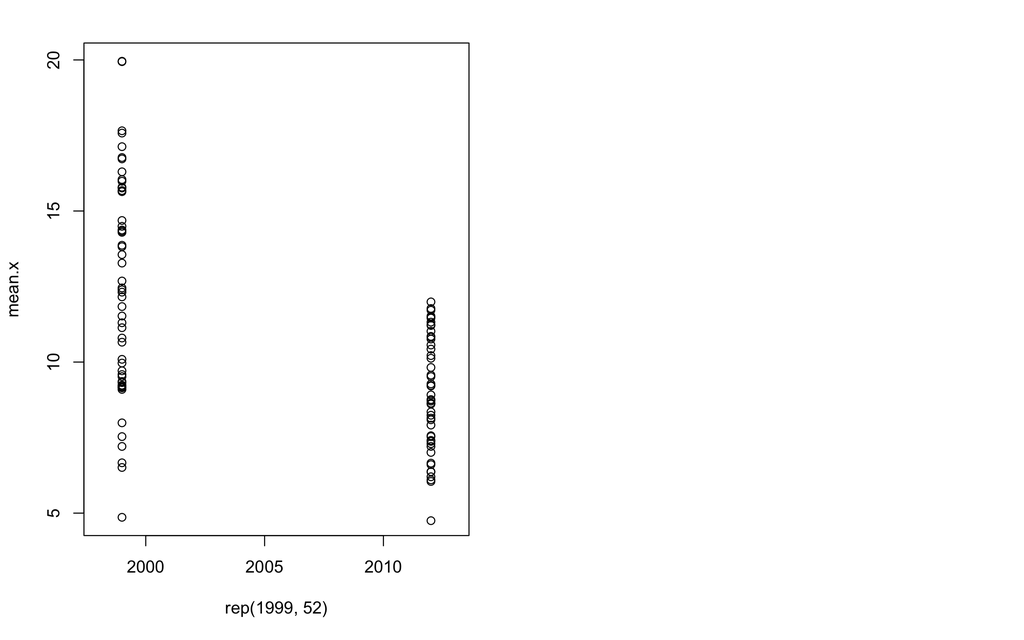

```r
par(mfrow = c(1, 2))
with(merged, plot(rep(1999, 52), mean.x, xlim = c(1998, 2013)))
with(merged, points(rep(2012, 52), mean.y))
```

```r
with(merged,
     plot(rep(1999, 52), mean.x, xlim = c(1998, 2013)), ylim=c(0, 20))
with(merged,
     points(rep(2012, 52), mean.y), ylim=c(0, 20))
```

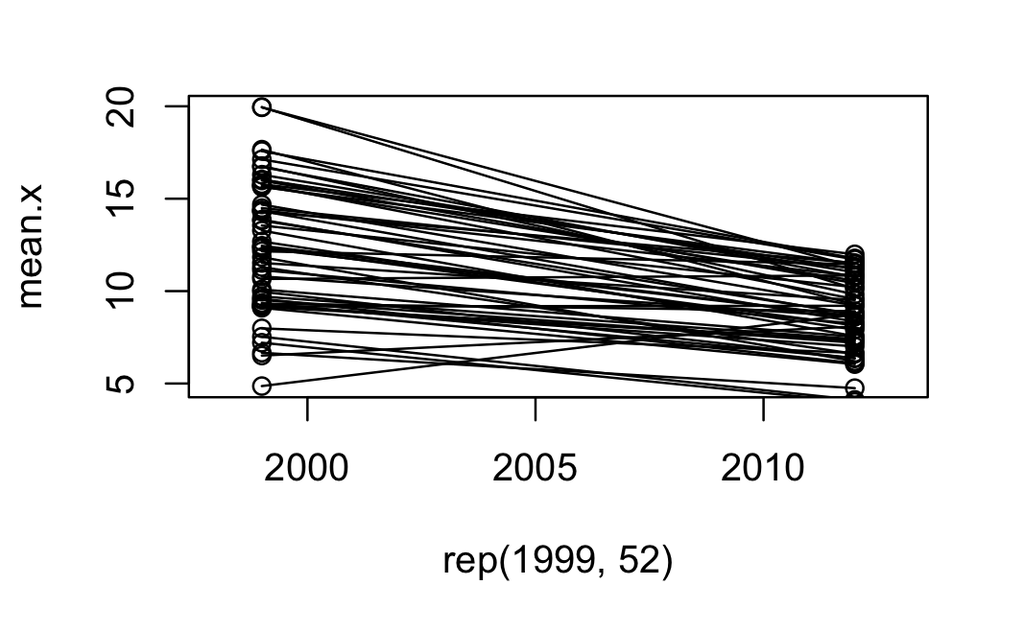

```r
segments(rep(1999, 52), merged[, 2], rep(2012, 52), merged[, 3])
```

We see from the plot that the vast majority of states have indeed improved their particulate matter counts so the general trend is downward. There are a few exceptions. (The topmost point in the 1999 column is actually two points that had very close measurements.)

For fun, let’s see which states had higher means in 2012 than in 1999. Just use the mrg[mrg$mean.x < mrg$mean.y, ] notation to find the rows of mrg with this particulate property.

```r
merged[merged$mean.x < merged$mean.y, ]
```

|  | state | mean.x | mean.y |
| --- | --- | --- | --- |
| 6 | 15 | 4.861821 | 8.749336 |
| 23 | 31 | 9.167770 | 9.207489 |
| 27 | 35 | 6.511285 | 8.089755 |
| 33 | 40 | 10.657617 | 10.849870 |

This concludes the lesson, comparing air pollution data from two years in different ways. First, we looked at measures of the entire set of monitors, then we compared the two measures from a particular monitor, and finally, we looked a the mean measures of the individual states.